# Regression Battleship - Creating your Data

Brynn Gifford

[figure not shown]

```r
pacman::p_load(car, callr, cluster, curl, data.table, DBI, dbplyr, downloader, dplyr, DT, dygraphs, d3heatmap, Ecdat, forcats, fs, geofacet, ggplot2, haven, htmltools, htmlwidgets, knitr, labeling, lubridate, markdown, MASS, mosaic, mosaicData, patchwork, plotly, plyr, pander, purrr, quantmod, readr, readxl, rio, sf, swirl, tidyquant, tidyr, tidyselect, tidyverse, timetk, yaml)
```

## Creating your Data

Remember the rules…

### Rules

1. Your csv must contain 11 columns of data.
   - The first column must be your (1) Y-variable (labeled as “Y”).
   - The other ten columns must be (10) X-variables (labeled as “X1”, “X2”, … , “X10”).
2. Your Y-variable (or some transformation of the Y-variable) must have been created from a linear regression model using only X-variables (or transformations of those X-variables) from within your data set.
   - Be very careful with transformations. You must ensure that you do not break the rules of a linear regression if you choose to use transformations.
   - If you choose transformations, only these functions are allowed when transforming X and Y variables: 1/Y^2, 1/Y, log(Y), sqrt(Y), Y^2, Y^3, 1/X^2, 1/X, log(X), sqrt(X), X^2, X^3, X^4, X^5. Don’t forget to check Rule #3 carefully if you choose transformations.
3. Your sample size must be sufficiently large so that when the true model is fit to your data using lm(…), all p-values of X-variable terms (not including the intercept) found in the summary(…) are significant.
4. Must be 2D drawable.

### True Model

Write out your final “true” model in mathematical form. Make sure it matches your code.

$$\text{EXAMPLE:} \ Y_i = \beta_0 + \beta_1 X_{1i} + \beta_2 X_{8i} + \beta_3 X_{1i} X_{8i} + \beta_4 X_{9i} + \beta_5 X_{1i} X_{9i} + \beta_6 X_{3i} + \beta_7 X_{5i} X_{3i} X_{9i} + \beta_8 X_{1i}^2 X_{3i} + \beta_9 X_{5i} X_{8i} + \beta_10 X_{5i} X_{1i} + \beta_11 X_{1i}^2 X_{5i} + \beta_12 X_{10i} + \beta_13 X_{1i} X_{10i} + \epsilon_i$$

### The Code to Make the Data

```r
set.seed(23) #This ensures the randomness is the "same" everytime if you play the entire R-chunk as one entire piece of code. If you run lines separately, your data might not come out the same every time.

## To begin, decide on your sample size. (You may have to revise it later to ensure all values in your lm(...) are significant.)

 n <- 824

## Then, create 10 X-variables using functions like rnorm(n, mean, sd), rchisq(n, df), rf(n, df1, df2), rt(n, df), rbeta(n, a, b), runif(n, a, b) or sample(c(1,0), n, replace=TRUE)...
  #X5 <- rf(n, .2, 1)
  #X7 <- rnorm(n, -.6, 1.2)

 X1 <- runif(n, .3, .6) #replace this
 X2 <- runif(n, .6, .7) #replace this
 X3 <- sample(c(0,1), n, replace = TRUE) #replace this
 X4 <- runif(n, .5, .8) #replace this
 X5 <- sample(c(0,1), n, replace = TRUE) #replace this
 X6 <- runif(n, .6, .9) #replace this
 X7 <- runif(n, .7, 1) #replace this
 X8 <- sample(c(0,1), n, replace = TRUE) #replace this
 X9 <- sample(c(0,1), n, replace = TRUE) #replace this
 X10 <- sample(c(0,1), n, replace = TRUE) #replace this

## Then, create betas, errors (by choosing sigma), and Y

 beta0 <- -4
 beta1 <- 7
 beta2 <- 10
 beta3 <- -11
 beta4 <- 6
 beta5 <- -7.2
 beta6 <- 7
 beta7 <- -7
 beta8 <- 1
 beta9 <- 12
 beta10 <- -11
 beta11 <- -1.5
 beta12 <- 1.8
 beta13 <- -6.5

 sigma <- 0.23 #change to whatever you want


 ################################
 # You CANNOT change this part:
 errors <- rnorm(n, 0, sigma)
 ################################

 #An example of how to make Y...
 # Y <-  beta0 + beta1*X1 + beta2*X2 + beta3*X4*X2 + errors

 #Y <- 0 #...edit this code and replace it with your model
 Y <- beta0 + beta1*X1 + beta2*X8 + beta3*X1*X8 + beta4*X9 + beta5*X1*X9 + beta6*X3 + beta7*X5*X3*X9 + beta8*X1^2*X3 + beta9*X8*X5 + beta10*X1*X5 + beta11*X1^2*X5 + beta12*X10 + beta13*X1*X10 + errors
   # You can include Y' or X' instead of Y or X if you wish.
 # Remember, only these functions are allowed when transforming
 # variables: 1/Y^2, 1/Y, log(Y), sqrt(Y), Y^2, Y^3, 1/X^2, 1/X, log(X), sqrt(X), X^2, X^3, X^4, X^5.
 #########################################################
 # ILLEGAL: Y = (beta0 + beta1*X5)^2 + epsilon ###########
 #########################################################
 # Legal: sqrt(Y) = beta0 + beta1*X5^2 + epsilon #########
 #########################################################
 # You can only transform individual terms, not groups of terms.
 # And the beta's cannot be part of the transformation.


 # Load your data into a data set:
 RBdata <- data.frame(Y, X1, X2, X3, X4, X5, X6, X7, X8, X9, X10)

 #Now fit your model to make sure it comes out significant:
 mylm <- lm(Y ~ X1 + X8 + X1:X8 + X9 + X1:X9 + X3 + X5:X3:X9 + I(X1^2):X3 + X5:X8 + X1:X5 +I(X1^2):X5 + X10 + X1:X10, data=RBdata) #edit this code
pander(summary(mylm))
```

|  | Estimate | Std. Error | t value | Pr(>\|t\|) |
| --- | --- | --- | --- | --- |
| **(Intercept)** | -3.963 | 0.09722 | -40.76 | 2.075e-198 |
| **X1** | 6.952 | 0.2113 | 32.9 | 2.163e-151 |
| **X8** | 9.914 | 0.0866 | 114.5 | 0 |
| **X9** | 5.92 | 0.08599 | 68.85 | 0 |
| **X3** | 7.049 | 0.04683 | 150.5 | 0 |
| **X10** | 1.805 | 0.08453 | 21.35 | 1.335e-80 |
| **X1:X8** | -10.85 | 0.1826 | -59.41 | 1.742e-297 |
| **X1:X9** | -7.006 | 0.1838 | -38.12 | 6.784e-183 |
| **X3:I(X1^2)** | 0.7233 | 0.2014 | 3.592 | 0.0003477 |
| **X8:X5** | 12.06 | 0.03201 | 376.9 | 0 |
| **X1:X5** | -11.15 | 0.2244 | -49.68 | 4.346e-248 |
| **X5:I(X1^2)** | -1.296 | 0.4318 | -3.002 | 0.002765 |
| **X1:X10** | -6.519 | 0.1827 | -35.68 | 2.587e-168 |
| **X9:X3:X5** | -6.991 | 0.03224 | -216.9 | 0 |

Fitting linear model: Y ~ X1 + X8 + X1:X8 + X9 + X1:X9 + X3 + X5:X3:X9 + I(X1^2):X3 + X5:X8 + X1:X5 + I(X1^2):X5 + X10 + X1:X10

| Observations | Residual Std. Error | $R^2$ | Adjusted $R^2$ |
| --- | --- | --- | --- |
| 824 | 0.2284 | 0.999 | 0.999 |

```r
 #all p-values must be significant, except "(Intercept)"
Y ~ X1 + X3 + X8 + X9 + X10 + X1:X5 + X1:X8 + X5:X8 + X1:X9 + X1:X10 + X3:X5:X9
```

```
## Y ~ X1 + X3 + X8 + X9 + X10 + X1:X5 + X1:X8 + X5:X8 + X1:X9 +
##     X1:X10 + X3:X5:X9
```

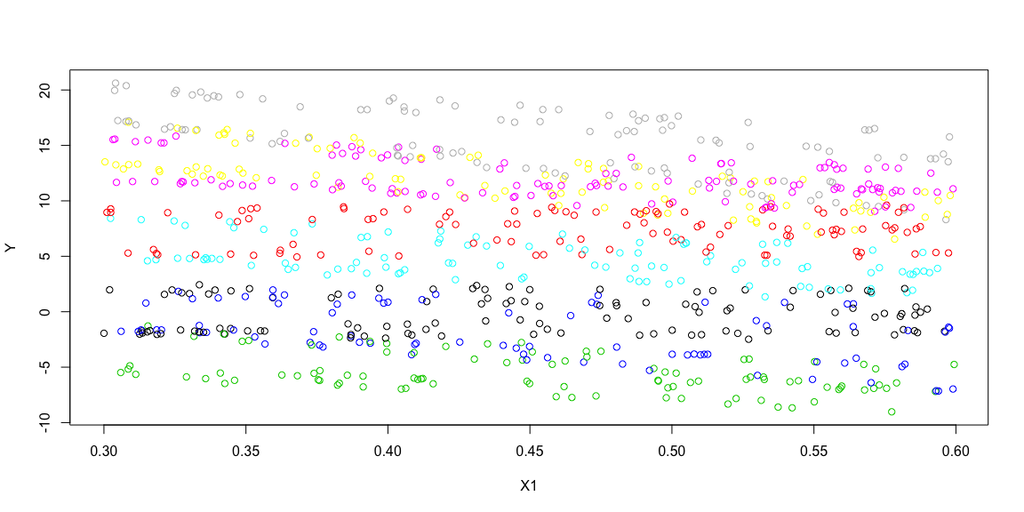

```r
 #Plot your True model along with the correct estimated model
 #(Model must be visualizable with a 2D scatterplot.)

#pairs(RBdata, panel=panel.smooth)
plot(Y ~ X1, data = RBdata, col = droplevels(interaction(RBdata$X3,RBdata$X5,RBdata$X8,RBdata$X9, RBdata$X10)))
```

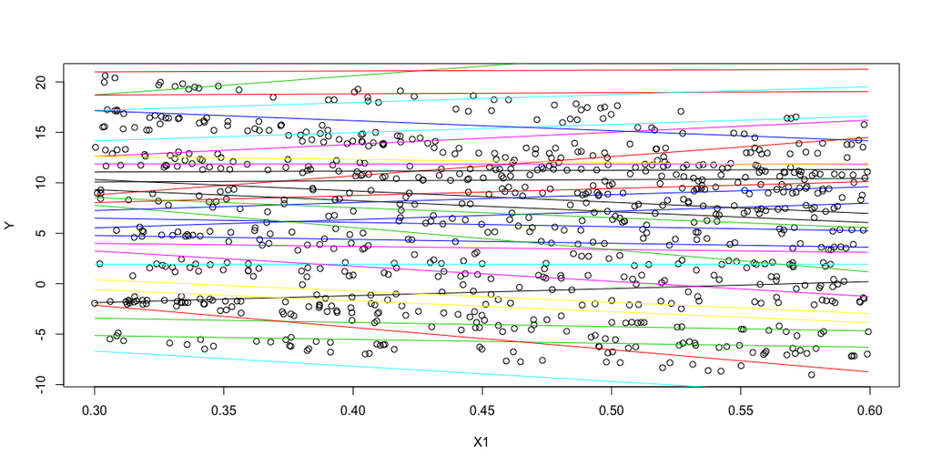

```r
b <- coef(mylm)

plot(Y~X1, data = RBdata)

x <- RBdata$X1

X3=0;X5=0;X8=0;X9=0;X10=0;
curve(b[1] + b[2]*X1 + b[3]*X3 + b[4]*X8 + b[5]*X9 + b[6]*X10 + b[7]*X1*X5 + b[8]*X1*X8 + b[9]*X5*X8 + b[10]*X1*X9 + b[11]*X1*X10 + b[12]*X3*X5*X9, add=TRUE, xname="X1", col=palette()[1])

X3=1;X5=0;X8=0;X9=0;X10=0;
curve(b[1] + b[2]*X1 + b[3]*X3 + b[4]*X8 + b[5]*X9 + b[6]*X10 + b[7]*X1*X5 + b[8]*X1*X8 + b[9]*X5*X8 + b[10]*X1*X9 + b[11]*X1*X10 + b[12]*X3*X5*X9, add=TRUE, xname="X1", col=palette()[2])

X3=0;X5=1;X8=0;X9=0;X10=0;
curve(b[1] + b[2]*X1 + b[3]*X3 + b[4]*X8 + b[5]*X9 + b[6]*X10 + b[7]*X1*X5 + b[8]*X1*X8 + b[9]*X5*X8 + b[10]*X1*X9 + b[11]*X1*X10 + b[12]*X3*X5*X9, add=TRUE, xname="X1", col=palette()[3])


X3=1;X5=1;X8=0;X9=0;X10=0;
curve(b[1] + b[2]*X1 + b[3]*X3 + b[4]*X8 + b[5]*X9 + b[6]*X10 + b[7]*X1*X5 + b[8]*X1*X8 + b[9]*X5*X8 + b[10]*X1*X9 + b[11]*X1*X10 + b[12]*X3*X5*X9, add=TRUE, xname="X1", col=palette()[4])

X3=0;X5=0;X8=1;X9=0;X10=0;
curve(b[1] + b[2]*X1 + b[3]*X3 + b[4]*X8 + b[5]*X9 + b[6]*X10 + b[7]*X1*X5 + b[8]*X1*X8 + b[9]*X5*X8 + b[10]*X1*X9 + b[11]*X1*X10 + b[12]*X3*X5*X9, add=TRUE, xname="X1", col=palette()[5])

X3=1;X5=0;X8=1;X9=0;X10=0;
curve(b[1] + b[2]*X1 + b[3]*X3 + b[4]*X8 + b[5]*X9 + b[6]*X10 + b[7]*X1*X5 + b[8]*X1*X8 + b[9]*X5*X8 + b[10]*X1*X9 + b[11]*X1*X10 + b[12]*X3*X5*X9, add=TRUE, xname="X1", col=palette()[6])

X3=0;X5=1;X8=1;X9=0;X10=0;
curve(b[1] + b[2]*X1 + b[3]*X3 + b[4]*X8 + b[5]*X9 + b[6]*X10 + b[7]*X1*X5 + b[8]*X1*X8 + b[9]*X5*X8 + b[10]*X1*X9 + b[11]*X1*X10 + b[12]*X3*X5*X9, add=TRUE, xname="X1", col=palette()[7])

X3=1;X5=1;X8=1;X9=0;X10=0;
curve(b[1] + b[2]*X1 + b[3]*X3 + b[4]*X8 + b[5]*X9 + b[6]*X10 + b[7]*X1*X5 + b[8]*X1*X8 + b[9]*X5*X8 + b[10]*X1*X9 + b[11]*X1*X10 + b[12]*X3*X5*X9, add=TRUE, xname="X1", col=palette()[1])

X3=0;X5=0;X8=0;X9=1;X10=0;
curve(b[1] + b[2]*X1 + b[3]*X3 + b[4]*X8 + b[5]*X9 + b[6]*X10 + b[7]*X1*X5 + b[8]*X1*X8 + b[9]*X5*X8 + b[10]*X1*X9 + b[11]*X1*X10 + b[12]*X3*X5*X9, add=TRUE, xname="X1", col=palette()[2])

X3=1;X5=0;X8=0;X9=1;X10=0;
curve(b[1] + b[2]*X1 + b[3]*X3 + b[4]*X8 + b[5]*X9 + b[6]*X10 + b[7]*X1*X5 + b[8]*X1*X8 + b[9]*X5*X8 + b[10]*X1*X9 + b[11]*X1*X10 + b[12]*X3*X5*X9, add=TRUE, xname="X1", col=palette()[3])

X3=0;X5=1;X8=0;X9=1;X10=0;
curve(b[1] + b[2]*X1 + b[3]*X3 + b[4]*X8 + b[5]*X9 + b[6]*X10 + b[7]*X1*X5 + b[8]*X1*X8 + b[9]*X5*X8 + b[10]*X1*X9 + b[11]*X1*X10 + b[12]*X3*X5*X9, add=TRUE, xname="X1", col=palette()[4])

X3=1;X5=1;X8=0;X9=1;X10=0;
curve(b[1] + b[2]*X1 + b[3]*X3 + b[4]*X8 + b[5]*X9 + b[6]*X10 + b[7]*X1*X5 + b[8]*X1*X8 + b[9]*X5*X8 + b[10]*X1*X9 + b[11]*X1*X10 + b[12]*X3*X5*X9, add=TRUE, xname="X1", col=palette()[5])


X3=0;X5=0;X8=1;X9=1;X10=0;
curve(b[1] + b[2]*X1 + b[3]*X3 + b[4]*X8 + b[5]*X9 + b[6]*X10 + b[7]*X1*X5 + b[8]*X1*X8 + b[9]*X5*X8 + b[10]*X1*X9 + b[11]*X1*X10 + b[12]*X3*X5*X9, add=TRUE, xname="X1", col=palette()[6])


X3=1;X5=0;X8=1;X9=1;X10=0;
curve(b[1] + b[2]*X1 + b[3]*X3 + b[4]*X8 + b[5]*X9 + b[6]*X10 + b[7]*X1*X5 + b[8]*X1*X8 + b[9]*X5*X8 + b[10]*X1*X9 + b[11]*X1*X10 + b[12]*X3*X5*X9, add=TRUE, xname="X1", col=palette()[7])


X3=0;X5=1;X8=1;X9=1;X10=0;
curve(b[1] + b[2]*X1 + b[3]*X3 + b[4]*X8 + b[5]*X9 + b[6]*X10 + b[7]*X1*X5 + b[8]*X1*X8 + b[9]*X5*X8 + b[10]*X1*X9 + b[11]*X1*X10 + b[12]*X3*X5*X9, add=TRUE, xname="X1", col=palette()[1])

X3=1;X5=1;X8=1;X9=1;X10=0;
curve(b[1] + b[2]*X1 + b[3]*X3 + b[4]*X8 + b[5]*X9 + b[6]*X10 + b[7]*X1*X5 + b[8]*X1*X8 + b[9]*X5*X8 + b[10]*X1*X9 + b[11]*X1*X10 + b[12]*X3*X5*X9, add=TRUE, xname="X1", col=palette()[2])

X3=0;X5=0;X8=0;X9=0;X10=1;
curve(b[1] + b[2]*X1 + b[3]*X3 + b[4]*X8 + b[5]*X9 + b[6]*X10 + b[7]*X1*X5 + b[8]*X1*X8 + b[9]*X5*X8 + b[10]*X1*X9 + b[11]*X1*X10 + b[12]*X3*X5*X9, add=TRUE, xname="X1", col=palette()[3])

X3=1;X5=0;X8=0;X9=0;X10=1;
curve(b[1] + b[2]*X1 + b[3]*X3 + b[4]*X8 + b[5]*X9 + b[6]*X10 + b[7]*X1*X5 + b[8]*X1*X8 + b[9]*X5*X8 + b[10]*X1*X9 + b[11]*X1*X10 + b[12]*X3*X5*X9, add=TRUE, xname="X1", col=palette()[4])

X3=0;X5=1;X8=0;X9=0;X10=1;
curve(b[1] + b[2]*X1 + b[3]*X3 + b[4]*X8 + b[5]*X9 + b[6]*X10 + b[7]*X1*X5 + b[8]*X1*X8 + b[9]*X5*X8 + b[10]*X1*X9 + b[11]*X1*X10 + b[12]*X3*X5*X9, add=TRUE, xname="X1", col=palette()[5])


X3=1;X5=1;X8=0;X9=0;X10=1;
curve(b[1] + b[2]*X1 + b[3]*X3 + b[4]*X8 + b[5]*X9 + b[6]*X10 + b[7]*X1*X5 + b[8]*X1*X8 + b[9]*X5*X8 + b[10]*X1*X9 + b[11]*X1*X10 + b[12]*X3*X5*X9, add=TRUE, xname="X1", col=palette()[6])

X3=0;X5=0;X8=1;X9=0;X10=1;
curve(b[1] + b[2]*X1 + b[3]*X3 + b[4]*X8 + b[5]*X9 + b[6]*X10 + b[7]*X1*X5 + b[8]*X1*X8 + b[9]*X5*X8 + b[10]*X1*X9 + b[11]*X1*X10 + b[12]*X3*X5*X9, add=TRUE, xname="X1", col=palette()[7])


X3=1;X5=0;X8=1;X9=0;X10=1;
curve(b[1] + b[2]*X1 + b[3]*X3 + b[4]*X8 + b[5]*X9 + b[6]*X10 + b[7]*X1*X5 + b[8]*X1*X8 + b[9]*X5*X8 + b[10]*X1*X9 + b[11]*X1*X10 + b[12]*X3*X5*X9, add=TRUE, xname="X1", col=palette()[1])


X3=0;X5=1;X8=1;X9=0;X10=1;
curve(b[1] + b[2]*X1 + b[3]*X3 + b[4]*X8 + b[5]*X9 + b[6]*X10 + b[7]*X1*X5 + b[8]*X1*X8 + b[9]*X5*X8 + b[10]*X1*X9 + b[11]*X1*X10 + b[12]*X3*X5*X9, add=TRUE, xname="X1", col=palette()[2])

X3=1;X5=1;X8=1;X9=0;X10=1;
curve(b[1] + b[2]*X1 + b[3]*X3 + b[4]*X8 + b[5]*X9 + b[6]*X10 + b[7]*X1*X5 + b[8]*X1*X8 + b[9]*X5*X8 + b[10]*X1*X9 + b[11]*X1*X10 + b[12]*X3*X5*X9, add=TRUE, xname="X1", col=palette()[3])

X3=0;X5=0;X8=0;X9=1;X10=1;
curve(b[1] + b[2]*X1 + b[3]*X3 + b[4]*X8 + b[5]*X9 + b[6]*X10 + b[7]*X1*X5 + b[8]*X1*X8 + b[9]*X5*X8 + b[10]*X1*X9 + b[11]*X1*X10 + b[12]*X3*X5*X9, add=TRUE, xname="X1", col=palette()[4])

X3=1;X5=0;X8=0;X9=1;X10=1;
curve(b[1] + b[2]*X1 + b[3]*X3 + b[4]*X8 + b[5]*X9 + b[6]*X10 + b[7]*X1*X5 + b[8]*X1*X8 + b[9]*X5*X8 + b[10]*X1*X9 + b[11]*X1*X10 + b[12]*X3*X5*X9, add=TRUE, xname="X1", col=palette()[5])

X3=0;X5=1;X8=0;X9=1;X10=1;
curve(b[1] + b[2]*X1 + b[3]*X3 + b[4]*X8 + b[5]*X9 + b[6]*X10 + b[7]*X1*X5 + b[8]*X1*X8 + b[9]*X5*X8 + b[10]*X1*X9 + b[11]*X1*X10 + b[12]*X3*X5*X9, add=TRUE, xname="X1", col=palette()[6])

X3=1;X5=1;X8=0;X9=1;X10=1;
curve(b[1] + b[2]*X1 + b[3]*X3 + b[4]*X8 + b[5]*X9 + b[6]*X10 + b[7]*X1*X5 + b[8]*X1*X8 + b[9]*X5*X8 + b[10]*X1*X9 + b[11]*X1*X10 + b[12]*X3*X5*X9, add=TRUE, xname="X1", col=palette()[7])

X3=0;X5=0;X8=1;X9=1;X10=1;
curve(b[1] + b[2]*X1 + b[3]*X3 + b[4]*X8 + b[5]*X9 + b[6]*X10 + b[7]*X1*X5 + b[8]*X1*X8 + b[9]*X5*X8 + b[10]*X1*X9 + b[11]*X1*X10 + b[12]*X3*X5*X9, add=TRUE, xname="X1", col=palette()[1])

X3=1;X5=0;X8=1;X9=1;X10=1;
curve(b[1] + b[2]*X1 + b[3]*X3 + b[4]*X8 + b[5]*X9 + b[6]*X10 + b[7]*X1*X5 + b[8]*X1*X8 + b[9]*X5*X8 + b[10]*X1*X9 + b[11]*X1*X10 + b[12]*X3*X5*X9, add=TRUE, xname="X1", col=palette()[2])

X3=0;X5=1;X8=1;X9=1;X10=1;
curve(b[1] + b[2]*X1 + b[3]*X3 + b[4]*X8 + b[5]*X9 + b[6]*X10 + b[7]*X1*X5 + b[8]*X1*X8 + b[9]*X5*X8 + b[10]*X1*X9 + b[11]*X1*X10 + b[12]*X3*X5*X9, add=TRUE, xname="X1", col=palette()[3])

X3=1;X5=1;X8=1;X9=1;X10=1;
curve(b[1] + b[2]*X1 + b[3]*X3 + b[4]*X8 + b[5]*X9 + b[6]*X10 + b[7]*X1*X5 + b[8]*X1*X8 + b[9]*X5*X8 + b[10]*X1*X9 + b[11]*X1*X10 + b[12]*X3*X5*X9, add=TRUE, xname="X1", col=palette()[4])
```

```r
#pairs(cbind(R=mylm$res, fit=mylm$fit, RBdata), panel=panel.smooth)

#levels(droplevels(interaction(RBdata$X3,RBdata$X5,RBdata$X8,RBdata$X9, RBdata$X10)))
#levels(interaction(RBdata$X3,RBdata$X5,RBdata$X8,RBdata$X9, RBdata$X10))
```

```r
# Once you are ready, run this code to write your data to a csv:
write.csv(RBdata, "RBdata.csv", row.names=FALSE)
# The above code writes the dataset to your "current directory"
# To see where that is, use: getwd() in your Console.
# Find the data set and upload it to I-Learn.
```